# 20260412_vcf_filter_v3

2026-04-26

We reran all variants calling with new parameters for Freebayes (with *-p 100*) for it to generate proper QUAL values for variants and only keeping the variants with QUAL > 30.

## Filtering of variants from raw vcf

Below we show a summarized workflow of the whole process.

[interactive chart not shown]

### Identification of parental variants

Below we show the identified parental variants that either:

1. Detected in both parental populations.
2. Detected in only one parental population but has allele frequency > 0.5 (i.e. the majority of the population).

| Sample_ID | POS | EVIDENCE | Ratio | Parental_Variant |
| --- | --- | --- | --- | --- |
| Plate1C9 | 378770 | G:5 T:34 | 0.1282051 | No |
| Plate1B9 | 1166763 | GA:68 G:0 | 1.0000000 | Yes |
| Plate1C9 | 1166763 | GA:90 G:0 | 1.0000000 | Yes |
| Plate1B9 | 1602681 | ATT:14 A:0 | 1.0000000 | Yes |
| Plate1B9 | 1681625 | TAA:339 T:0 | 1.0000000 | Yes |
| Plate1C9 | 1681625 | TAA:452 T:0 | 1.0000000 | Yes |
| Plate1B9 | 1702756 | GA:41 G:0 | 1.0000000 | Yes |
| Plate1C9 | 1702756 | GA:40 G:0 | 1.0000000 | Yes |
| Plate1B9 | 1914986 | AG:24 TA:12 | 0.6666667 | Yes |
| Plate1C9 | 1914986 | AG,TG:22,3 TA:19 | 0.5365854 | Yes |
| Plate1B9 | 1931428 | CTT:22 C:0 | 1.0000000 | Yes |
| Plate1B9 | 1932330 | T:8 C:83 | 0.0879121 | Yes |
| Plate1C9 | 1932330 | T:8 C:108 | 0.0689655 | Yes |
| Plate1B9 | 1932335 | G:11 A:67 | 0.1410256 | Yes |
| Plate1C9 | 1932335 | G:7 A:99 | 0.0660377 | Yes |
| Plate1B9 | 1932344 | TATTGGTATGC,CATTGGTATGC,CATCGGTATGA:3,7,3 CATCGGCATGC:45 | 0.1346154 | Yes |
| Plate1C9 | 1932344 | TATTGGTATGC,CATTGGTATGC,CATCGGTATGA:4,5,5 CATCGGCATGC:69 | 0.0675676 | Yes |
| Plate1C9 | 1932344 | TATTGGTATGC,CATTGGTATGC,CATCGGTATGA:4,5,5 CATCGGCATGC:69 | 0.0675676 | Yes |
| Plate1C9 | 1939963 | CT:7 TA:18 | 0.2800000 | Yes |
| Plate1B9 | 1939963 | CT,CA:6,3 TA:9 | 0.4000000 | Yes |
| Plate1C9 | 2420681 | T,TGG:3,7 TG:106 | 0.0619469 | No |
| Plate1B9 | 3041477 | G:33 A:461 | 0.0668016 | Yes |
| Plate1C9 | 3041477 | G:35 A:610 | 0.0542636 | Yes |
| Plate1B9 | 3256546 | CTG,C:6,8 CTGTG:2 | 0.7500000 | Yes |
| Plate1B9 | 3256546 | CTG,C:6,8 CTGTG:2 | 0.8000000 | Yes |
| Plate1B9 | 3356587 | CT:251 C:0 | 1.0000000 | Yes |
| Plate1C9 | 3356587 | CT:323 C:1 | 0.9969136 | Yes |
| Plate1C9 | 3521509 | G:7 C:36 | 0.1627907 | No |
| Plate1B9 | 3929680 | TAA:10 T:0 | 1.0000000 | Yes |
| Plate1B9 | 4229448 | GT:7 G:125 | 0.0530303 | No |

## Update Figure 2 with new filtering

We then re-plotted figure 2 with the new filtering strategy.

The new figure layout looks:  
- **a** variant landscape over the genome that pass the strict filtering, with Xanthan gum and Loperamide related gene region highlighted  
- **b** Xanthan gum evolved strains’ variants associated to *acrR* gene  
- **c** Loperamide evolved strains’ variants associated to *trkH* and *trkA* genes.

Additionally, we used IGV to manually check each variants shown in Figure 2 panels related to Xanthan gum and Loperamide.

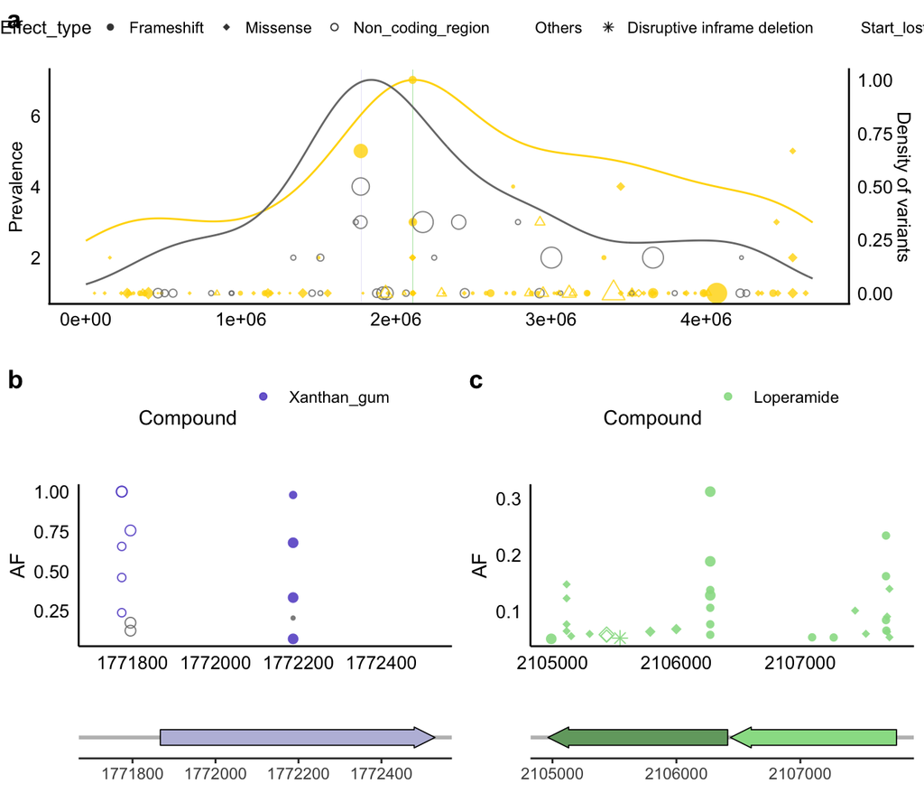

### Other Xenobiotic-Specific Transporter Variants

We also identified additional xenobiotic-specific transporter variants. For example, acarbose, an oral antidiabetic medication that inhibits intestinal α-glucosidases and thereby slows carbohydrate digestion, exhibited recurrent mutations (8 of 9 genetic variants detected across 6 of 8 evolved populations; see details below). These mutations were associated with the regulatory protein SusR, which modulates the sus operon in B. uniformis and may consequently affect its ability to utilize starch.

| Sample_ID | POS | EFFECT | EVIDENCE | PRODUCT | Ratio | Compound | Concentration |
| --- | --- | --- | --- | --- | --- | --- | --- |
| Plate1B1 | 4556588 | missense_variant c.1240A>T p.Ser414Cys | A:6 T:42 | Regulatory protein SusR | 0.1250000 | Acarbose | 25 |
| Plate1C1 | 4556588 | missense_variant c.1240A>T p.Ser414Cys | A:6 T:55 | Regulatory protein SusR | 0.0983607 | Acarbose | 25 |
| Plate1D1 | 4556588 | missense_variant c.1240A>T p.Ser414Cys | A:6 T:72 | Regulatory protein SusR | 0.0769231 | Acarbose | 25 |
| Plate1F1 | 4556588 | missense_variant c.1240A>T p.Ser414Cys | A:8 T:76 | Regulatory protein SusR | 0.0952381 | Acarbose | 50 |
| Plate1H1 | 4556588 | missense_variant c.1240A>T p.Ser414Cys | A:16 T:82 | Regulatory protein SusR | 0.1632653 | Acarbose | 50 |
| Plate1F1 | 4556630 | missense_variant c.1198G>A p.Glu400Lys | T:19 C:58 | Regulatory protein SusR | 0.2467532 | Acarbose | 50 |
| Plate1D1 | 4556689 | missense_variant c.1139T>A p.Leu380Gln | T:5 A:63 | Regulatory protein SusR | 0.0735294 | Acarbose | 25 |
| Plate1E1 | 4556689 | missense_variant c.1139T>A p.Leu380Gln | T:22 A:46 | Regulatory protein SusR | 0.3235294 | Acarbose | 50 |
| Plate1B1 | 4640181 | missense_variant c.1181A>C p.Asp394Ala | G:5 T:46 | Putative inner membrane protein | 0.0980392 | Acarbose | 25 |

Another example is loperamide: 4 of the 6 non-Trk related genetic variants detected in the population (total N = 37; 31 are shown in Figure 2c and are associated with the Trk potassium uptake system) are missense variants in a putative type IIS restriction–modification enzyme, which may reduce their resistance to virus when dysfunctional.

| Sample_ID | POS | EFFECT | PRODUCT | EVIDENCE | Ratio | Compound | Concentration |
| --- | --- | --- | --- | --- | --- | --- | --- |
| Plate2H10 | 464838 | Non-coding_region_variant |  | A:5 G:21 | 0.1923077 | Loperamide | 50 |
| Plate2A10 | 2493887 | frameshift_variant c.931delG p.Val311fs | 3-isopropylmalate dehydrogenase (EC 1.1.1.85) | A:16 AG:268 | 0.0563380 | Loperamide | 25 |
| Plate2B10 | 3447658 | missense_variant c.1645G>A p.Gly549Ser | putative type IIS restriction/modification enzyme | T:14 C:232 | 0.0569106 | Loperamide | 25 |
| Plate2D10 | 3447658 | missense_variant c.1645G>A p.Gly549Ser | putative type IIS restriction/modification enzyme | T:6 C:113 | 0.0504202 | Loperamide | 25 |
| Plate2E10 | 3447658 | missense_variant c.1645G>A p.Gly549Ser | putative type IIS restriction/modification enzyme | T:31 C:67 | 0.3163265 | Loperamide | 50 |
| Plate2H10 | 3447658 | missense_variant c.1645G>A p.Gly549Ser | putative type IIS restriction/modification enzyme | T:40 C:105 | 0.2758621 | Loperamide | 50 |